# ROOT Tutorial I：基本对象与分析

**代码语言：**PyROOT · ROOT C++

通过刻度和探测器实例，学习函数、图、随机采样、直方图、基本拟合及 ROOT 文件读写。

先按需阅读 Python 基础。本页示例介绍作业 1–3 中用到的 ROOT 操作。

在 PyROOT notebook 中按顺序运行单元格。选择一种代码语言即可，两种版本采用相同的示例和文件格式。

## 0. 交互式使用 ROOT

用 `import ROOT` 加载 PyROOT，随后通过 `ROOT` 模块调用 ROOT 的类和函数。下面先输出版本号，便于排查不同系统上的运行差异。`ROOT.gROOT` 是 ROOT 的全局对象，这里只使用它的 `GetVersion()` 方法。

```
import ROOT

print(f"ROOT version: {ROOT.gROOT.GetVersion()}")
```

```
ROOT version: 6.40.02
```

JSROOT 可在 Jupyter 中交互式显示 ROOT 图。`%jsroot on` 是 Jupyter 命令，不是普通 Python 语句，通常只需运行一次。若当前安装不提供该命令，可跳过此单元格，使用该环境已配置的显示方式。

```
%jsroot on
```

ROOT 将函数、图和直方图绘制在画布 `TCanvas` 上。下面使用的构造函数为

```
ROOT.TCanvas(name, title, width, height)
```

`name` 是画布在 ROOT 中的内部名称，同一会话中应避免重复；`title` 是画布标题；`width` 和 `height` 是初始宽、高，单位为像素。本教程重复使用同一画布：`Clear()` 清除先前的绘图而不删除这里绘制的对象，`Draw()` 则在 notebook 中显示当前画布。

`SetOptStat(0)` 隐藏自动统计框；需要的数值在相应代码中输出。

```
ROOT.gStyle.SetOptStat(0)
c1 = ROOT.TCanvas("c1", "ROOT Tutorial I", 800, 520)
```

ROOT 的数学函数可通过 `ROOT.TMath` 调用。先用下面的单元格熟悉调用方式，再创建 ROOT 对象。

```
x = 2.0
print("sqrt(2) =", ROOT.TMath.Sqrt(x))
print("pi      =", ROOT.TMath.Pi())
```

```
sqrt(2) = 1.4142135623730951
pi      = 3.141592653589793
```

**类（class）**定义对象的类型，例如 `ROOT.TCanvas` 和 `ROOT.TF1`。调用构造函数可创建一个**对象（object）**，如 `c1` 是一个具体画布。对象提供的操作称为**方法（method）**，如 `c1.Clear()`。

PyROOT 用点号调用方法：

```
object.Method(arguments)
```

ROOT 文档常给出 C++ 写法 `object->Method(arguments)`。PyROOT 用 `.` 代替 `->`，也不需要写 C++ 中的指针声明 `Type*` 和 `new`；调用的 ROOT 类和方法本身相同。

## 1. `TF1`：一维函数

`TF1` 表示单个自变量的数学函数，常用于能量刻度曲线、峰形和本底模型。它保存公式和参数值，不保存逐个测量事例。

本节使用的构造函数为

```
ROOT.TF1(name, formula, xmin, xmax)
```

`name` 是 ROOT 内部名称，`formula` 是包含数学表达式的字符串；`xmin`、`xmax` 给出函数计算和绘制的范围。自变量写作 `x`，可调参数依次写作 `[0]`、`[1]` 等。

### 1.1 线性刻度函数

探测器及其电子学通常给出 ADC channel，而不是以 keV 为单位的能量。在适当范围内，可以先用线性关系描述能量刻度：

$$ E = a + b \times \text{channel}. $$

ROOT 公式中的 `[0]` 表示零点偏移 `a`，`[1]` 表示增益 `b`。下面将函数定义在 channel 0–4000 范围内。

```
fcal = ROOT.TF1("fcal", "[0] + [1]*x", 0.0, 4000.0)
fcal.SetParNames("offset", "gain")
fcal.SetParameters(0.2, 0.5)
fcal.SetTitle("Linear calibration;Channel;Energy (keV)")

c1.Clear()
fcal.Draw()
c1.Draw()
```

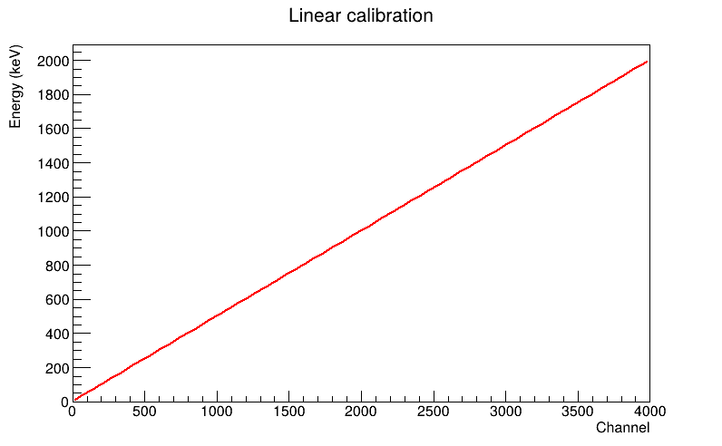

`SetParNames` 为 `[0]`、`[1]` 设置便于辨认的参数名称，不设置数值。`SetParameters(0.2, 0.5)` 再按顺序设置零点偏移和增益，得到

$$ E = 0.2 + 0.5 \times \text{channel}. $$

ROOT 标题字符串用分号分隔图标题、x 轴标题和 y 轴标题：

```
main title;x-axis title;y-axis title
```

`fcal.Draw()` 将函数画在当前画布上，`c1.Draw()` 将画布显示在 Jupyter 中。这里的参数已经直接给定，没有进行拟合。

`Eval(value)` 计算指定自变量处的函数值，可用于按已知刻度关系将 channel 换算为能量。

```
channel = 1500.0
energy = fcal.Eval(channel)
print(f"Channel {channel:.0f} -> Energy = {energy:.1f} keV")
```

```
Channel 1500 -> Energy = 750.2 keV
```

### 1.2 Gaussian 峰形

辐射探测器的全能峰（full-energy peak）常先用 Gaussian 函数近似：

$$ f(E)=A\exp\left[-\frac{1}{2}\left(\frac{E-\mu}{\sigma}\right)^2\right]. $$

参数 `A`、`mu`、`sigma` 分别表示峰高、峰位和标准差，对应 ROOT 表达式中的 `[0]`、`[1]`、`[2]`。下面在 400–700 keV 范围内绘制函数。

```
fpeak = ROOT.TF1(
    "fpeak",
    "[0]*exp(-0.5*((x-[1])/[2])^2)",
    400.0,
    700.0,
)
fpeak.SetParNames("height", "centroid", "sigma")
fpeak.SetParameters(1000.0, 550.0, 20.0)
fpeak.SetTitle("Gaussian peak model;Energy (keV);Counts")

c1.Clear()
fpeak.Draw()
c1.Draw()
```

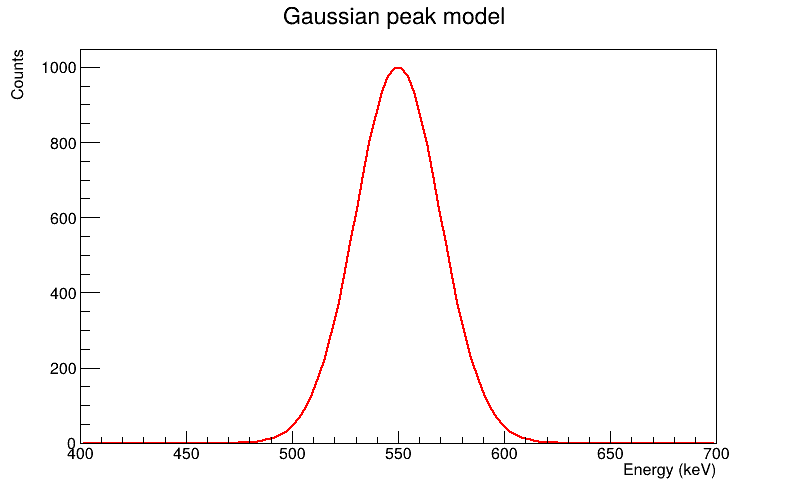

曲线在 550 keV 处的峰高为 1000，宽度参数为 \(\sigma=20\) keV。Gaussian 的半高全宽（FWHM）为

$$\mathrm{FWHM}=2\sqrt{2\ln 2}\,\sigma\approx2.355\sigma.$$

`TF1` 在这里仅定义曲线；第 3、4 节将生成逐个事例的能量，并填入直方图。

## 2. `TGraph`：数据点

`TGraph` 保存成对坐标 `(x_i, y_i)`，适合表示每个点都有明确坐标的数据，例如刻度峰的 channel 与已知能量。它保存传入的坐标，不划分 bin，也不自动统计重复测量的次数。

### 2.1 刻度数据点与误差

下面给出五组示意性的 channel–能量数据。实验中，每组数据来自一个已识别的 γ 峰：峰位拟合给出 channel 及其误差，核数据给出参考能量。这里假设参考能量误差可以忽略，并为 channel 给定一组示意误差，单位也是 channel。

数组中的同一索引对应同一个峰。误差应放在它所属的坐标轴上，不能将 channel 误差直接当作能量误差。

```
import numpy as np

ch = np.array([512.0, 1024.0, 1538.0, 2049.0, 2561.0], dtype=np.float64)
E = np.array([122.1, 245.4, 367.8, 489.0, 612.3], dtype=np.float64)

dch = np.array([1.0, 1.0, 2.0, 2.0, 3.0], dtype=np.float64)
dEref = np.zeros(len(ch), dtype=np.float64)
```

`TGraph(n, x, y)` 保存 n 对坐标；`TGraphErrors(n, x, y, ex, ey)` 进一步保存两个坐标的误差。下面横轴为 channel，纵轴为参考能量，所以第四、第五个数组分别为 channel 误差和能量误差。

`SetName` 设置保存到 ROOT 文件时使用的名称，`SetMarkerStyle(20)` 选择实心圆点。`Draw("AP")` 中 A 表示坐标轴，P 表示数据点；TGraphErrors 同时显示误差棒。

```
gcal = ROOT.TGraphErrors(len(ch), ch, E, dch, dEref)
gcal.SetName("gcal")
gcal.SetTitle("Energy calibration;Channel;Energy (keV)")
gcal.SetMarkerStyle(20)

c1.Clear()
gcal.Draw("AP")
c1.Draw()
```

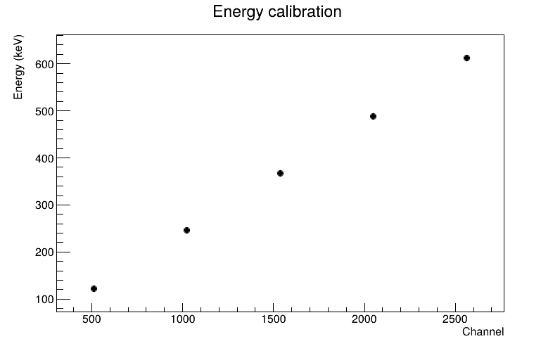

### 2.2 拟合刻度数据

ROOT 内置公式 `pol1` 表示 \(f(x)=[0]+[1]x\)。从数据大致估计斜率约为 0.24 keV/channel，用它设置拟合初值。

`Fit(flin, "RSF")` 中：R 使用函数定义的范围，S 返回拟合结果，F 让多项式也使用一般数值 minimizer。这里 channel 误差在 x 轴上，F 很重要：ROOT 的专用 linear fitter 会忽略 x 误差。一般拟合按函数斜率将 x 误差折算到能量方向。

```
flin = ROOT.TF1("flin", "pol1", 0.0, 3000.0)
flin.SetParNames("offset", "slope")
flin.SetParameters(0.0, 0.24)

calibration_fit = gcal.Fit(flin, "RSF")
c1.Draw()
```

```
Minimizer is Minuit2 / Migrad
Chi2                      =      10.8919
NDf                       =            3
Edm                       =  5.21828e-07
NCalls                    =           39
offset                    =    0.0914136   +/-   0.307312
slope                     =     0.239022   +/-   0.000258847
```

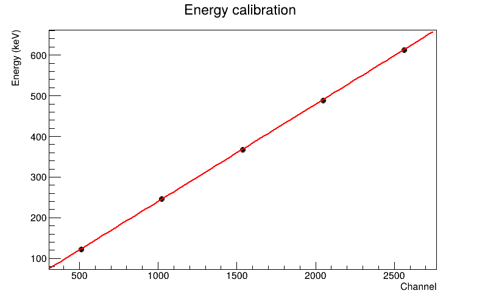

`GetParameter(i)` 读取拟合参数 `i`。参数 0 是零点偏移，单位为 keV；参数 1 是斜率，单位为 keV/channel。单位由坐标轴对应的物理量确定，ROOT 不会从数值中自动推断单位。

```
offset = flin.GetParameter(0)
slope = flin.GetParameter(1)
print("Fit status:", int(calibration_fit))
print("Offset:", offset, "+/-", flin.GetParError(0), "keV")
print("Slope:", slope, "+/-", flin.GetParError(1), "keV/channel")
```

```
Fit status: 0
Offset: 0.09141363127154742 +/- 0.3073116485098406 keV
Slope: 0.23902166824139454 +/- 0.0002588474870812204 keV/channel
```

状态码 0 表示数值拟合正常完成；模型是否合适还要结合残差判断。`GetParError(i)` 返回第 i 个参数的拟合误差。由多个参数共同计算一个量时，还需要考虑参数之间的协方差，参见加权拟合与误差传播。

### 2.3 逐点构造残差图

在完整刻度范围内，小的偏离容易被坐标尺度掩盖。逐点计算 \(E_{\rm ref}-f(\mathrm{channel})\)，用残差图查看偏离的位置和大小。

`SetPoint(i, x, y)` 设置第 i 个点，`SetPointError(i, ex, ey)` 设置其误差，索引从 0 开始。这里的误差棒显示原数据的测量误差尺度，折算为 \(|b|\sigma_{\rm channel}\)。

```
cal_residual = ROOT.TGraphErrors()
cal_residual.SetName("cal_residual")
for i in range(len(ch)):
    cal_residual.SetPoint(i, ch[i], E[i] - flin.Eval(ch[i]))
    cal_residual.SetPointError(i, 0, abs(slope) * dch[i])
cal_residual.SetTitle("Calibration residual;Channel;Reference - fitted energy (keV)")
cal_residual.SetMarkerStyle(20)
c1.Clear()
cal_residual.Draw("AP")
zero_cal = ROOT.TLine(ch[0], 0, ch[-1], 0)
zero_cal.SetLineStyle(2)
zero_cal.Draw()
c1.Draw()
```

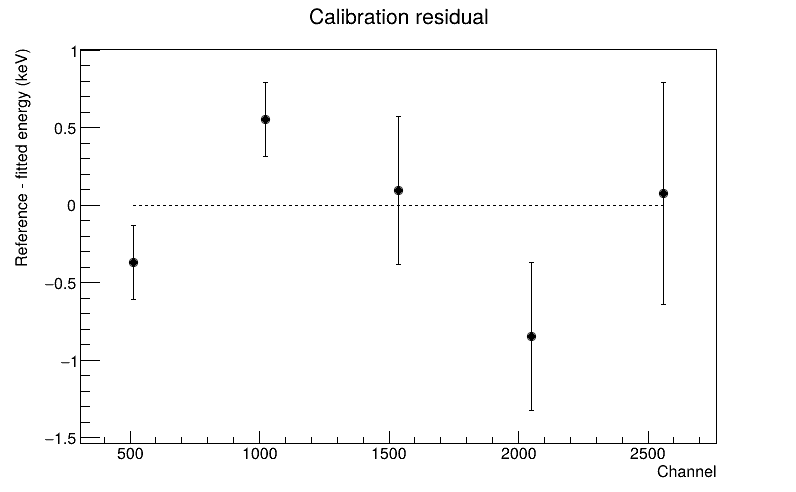

虚线对应零残差。本例有些点的偏离超过了给定的测量误差尺度，说明拟合收敛不等于数据与模型符合良好。实际刻度时，应检查峰的对应关系、峰位误差和线性刻度的适用范围；若残差随 channel 连续弯曲，尤其需要检查最后一项。

### 2.4 读入文本表格并插值

将calibration_points.txt 放在 notebook 所在目录。文件中第一列为 channel，第二列为能量（keV），与前面的五组坐标相同；该文件不含误差列。

`TGraph(filename, "%lg %lg")` 从每行读取两个浮点数，依次作为 x、y。先用 `GetN()` 检查读入的点数，再计算插值。

```
table = ROOT.TGraph("calibration_points.txt", "%lg %lg")
print("Read points:", table.GetN())
print("Interpolated energy:", table.Eval(1000.0), "keV")
print("Fitted energy:", flin.Eval(1000.0), "keV")
```

```
Read points: 5
Interpolated energy: 239.6203125 keV
Fitted energy: 239.11308187266607 keV
```

`TGraph::Eval` 默认在相邻数据点之间做线性插值；`TF1::Eval` 则计算拟合函数值，所以两个结果不必相同。用于射程、阻止本领等表格时，同样先确认两列的物理量、单位和覆盖范围，再选择合理的插值。

## 3. `TRandom3`：随机采样

`Gaus` 生成 Gaussian 测量涨落，`Uniform` 生成均匀分布数值，`Poisson` 生成固定时长内的计数。这三种方法都可由同一个随机数发生器调用。

构造函数为

```
ROOT.TRandom3(seed)
```

随机种子（seed）确定发生器的初始状态。每次用同一个正整数种子重新创建发生器，会得到相同序列，便于复现教程结果；换一个种子，则得到来自同一概率分布的另一组随机样本。

先看 `Rndm()`：它不接收参数，每次返回一个 0–1 之间均匀分布的随机数，并将发生器的内部状态推进到下一步。

```
rng = ROOT.TRandom3(12345)

for i in range(5):
    print(f"sample {i}: {rng.Rndm():.6f}")
```

```
sample 0: 0.929616
sample 1: 0.890155
sample 2: 0.316376
sample 3: 0.130707
sample 4: 0.183919
```

用相同的正整数种子重新创建发生器，可以复现该序列。

### 3.1 Gaussian 展宽：模拟探测器分辨率

假设单能辐射沉积的真实能量为 548 keV，有限的探测器分辨率使重复测量值在附近涨落。方法

```
rng.Gaus(mean, sigma)
```

返回一个 Gaussian 随机数。`mean` 是中心值，`sigma` 是标准差，单位与结果相同。因此 `Gaus(548.0, 8.0)` 可表示一次可能的能量测量，单位为 keV。

```
E_true = 548.0   # keV
sigma_E = 8.0    # keV

for i in range(10):
    E_measured = rng.Gaus(E_true, sigma_E)
    print(f"measurement {i}: {E_measured:.3f} keV")
```

```
measurement 0: 537.891 keV
measurement 1: 553.223 keV
measurement 2: 541.708 keV
measurement 3: 540.530 keV
measurement 4: 542.628 keV
measurement 5: 554.556 keV
measurement 6: 554.827 keV
measurement 7: 561.549 keV
measurement 8: 553.479 keV
measurement 9: 547.698 keV
```

每次调用代表对同一真实能量的一次可能测量，十个结果并不是十种不同的 γ 射线能量。这里用 Gaussian 近似只考虑分辨率展宽，完整的探测器响应还可能包含其他成分。

### 3.2 均匀本底

方法

```
rng.Uniform(xmin, xmax)
```

返回 `xmin` 与 `xmax` 之间的实数。本例令 0–2000 keV 内的概率密度相同，用平坦本底演示不同分布的组合，不将其视为一般 γ 连续谱的物理模型。

```
for i in range(10):
    E_background = rng.Uniform(0.0, 2000.0)
    print(f"background sample {i}: {E_background:.3f} keV")
```

```
background sample 0: 747.842 keV
background sample 1: 1307.140 keV
background sample 2: 309.947 keV
background sample 3: 1495.430 keV
background sample 4: 1784.687 keV
background sample 5: 1922.613 keV
background sample 6: 53.579 keV
background sample 7: 16.777 keV
background sample 8: 583.005 keV
background sample 9: 212.889 keV
```

### 3.3 Poisson 计数涨落

事例相互独立、平均发生率恒定时，固定时长内的计数通常可用 Poisson 分布描述。方法

```
rng.Poisson(mean_count)
```

接收该时长内的期望计数，返回一个整数计数；参数不是计数上限。Poisson 分布的方差等于均值，因此标准差为 `sqrt(mean_count)`。

```
mean_count = 10.0  # 平均计数率为 10 Hz，测量 1 s
for i in range(10):
    print(rng.Poisson(mean_count))
```

```
18
13
10
12
11
9
6
9
15
11
```

`Gaus` 和 `Uniform` 返回能量等连续量，`Poisson` 返回离散的事例数。选哪种分布取决于所描述的实验量，而不是它们是否属于同一个随机数发生器。

## 4. `TH1`：一维直方图

直方图表示许多测量值或模拟值的分布。横轴划分为若干小区间，称为 bin。`Fill(value)` 找到 `value` 所在的 bin，并将其计数加一；直方图保存各 bin 的计数，不保存完整的原始数值列表。

`TH1` 是 ROOT 一维直方图的基类。本例使用 `TH1F`，其中 `F` 表示 bin 内容用单精度浮点数保存；`TH1D` 则使用双精度。对于本例的计数规模，两者都够用。

### 4.1 构造简单能谱

构造函数为

```
ROOT.TH1F(name, title, number_of_bins, xmin, xmax)
```

下面的直方图在 0–2000 keV 范围内有 400 个 bin，每个宽 5 keV。低于或超出范围的值进入专门的 underflow 或 overflow bin。

模型包含 30,000 个 548 keV 峰事例、18,000 个 1250 keV 峰事例，以及 30,000 个平坦本底事例。两个峰采用不同的 sigma，表示不同的测量宽度。这是一个简化能谱，用来练习组合随机样本并观察直方图。

```
hspec = ROOT.TH1F(
    "hspec",
    "Simulated energy spectrum;Energy (keV);Counts per 5 keV",
    400,
    0.0,
    2000.0,
)

r1 = ROOT.TRandom3(24680)

for i in range(30000):
    hspec.Fill(r1.Gaus(548.0, 10.0))

for i in range(18000):
    hspec.Fill(r1.Gaus(1250.0, 18.0))

for i in range(30000):
    hspec.Fill(r1.Uniform(0.0, 2000.0))

c1.Clear()
hspec.Draw()
c1.Draw()
```

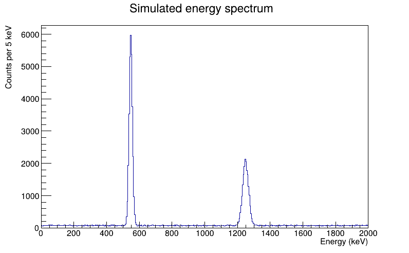

每个循环加入一种成分，每次生成一个能量并传给 `Fill`。循环次数控制该成分的事例总数，不是峰的最大高度，因为峰事例会分布在多个 bin 中。不带选项的 `Draw()` 使用 ROOT 默认的一维直方图样式。

### 4.2 查看直方图信息

`GetEntries()` 返回 `Fill` 的调用次数，包括进入 underflow 和 overflow 的事例。`GetMean()`、`GetStdDev()` 描述直方图整体分布；`GetNbinsX()` 返回 x 轴普通 bin 的个数，`GetBinWidth(1)` 返回第一个 bin 的宽度。本例所有普通 bin 等宽。

```
print(f"Entries     = {hspec.GetEntries():.0f}")
print(f"Number bins = {hspec.GetNbinsX()}")
print(f"Bin width   = {hspec.GetXaxis().GetBinWidth(1):.1f} keV")
print(f"Mean        = {hspec.GetMean():.3f} keV")
print(f"Std dev         = {hspec.GetStdDev():.3f} keV")
```

```
Entries     = 78000
Number bins = 400
Bin width   = 5.0 keV
Mean        = 882.077 keV
Std dev         = 456.857 keV
```

总事例数应为 `30000 + 18000 + 30000 = 78000`。输出中的 Mean 和 Std dev 对应两个峰加本底的整体分布，不是某个峰的峰位和分辨率。单个峰的性质应通过选定峰区或适当拟合提取。

### 4.2.1 用 sidebands 拟合局部本底

先用 480–510 keV 和 590–620 keV 两段 sidebands 描述峰附近的局部本底。每个 bin 的中心和计数构成一个 `TGraphErrors` 点，计数误差取 \(\sqrt{n}\)。只用这些点拟合 `pol1`，避免 Gaussian 峰影响本底初值。

红点是参与本底拟合的 bin，绿色直线是拟合结果，并向峰下延伸。sidebands 应避开峰尾和邻峰；真实能谱还需要检查线性本底是否足够。

```
sideband = ROOT.TGraphErrors()
for b in range(hspec.FindBin(480), hspec.FindBin(620)):
    x = hspec.GetBinCenter(b)
    if x < 510 or x >= 590:
        y = hspec.GetBinContent(b)
        i = sideband.GetN()
        sideband.SetPoint(i, x, y)
        sideband.SetPointError(i, 0, ROOT.TMath.Sqrt(max(y, 1.0)))

background_line = ROOT.TF1("background_line", "pol1", 480, 620)
background_line.SetParameters(75, 0)
background_result = sideband.Fit(background_line, "RSQ0")
print("Background fit status:", int(background_result))
print("p0:", background_line.GetParameter(0))
print("p1:", background_line.GetParameter(1), "counts/bin/keV")

hspec.GetXaxis().SetRangeUser(470, 630)
c1.Clear()
hspec.Draw("E")
sideband.SetMarkerStyle(20)
sideband.SetMarkerColor(ROOT.kRed + 1)
sideband.Draw("P SAME")
background_line.SetLineColor(ROOT.kGreen + 2)
background_line.Draw("SAME")
c1.Draw()
```

```
Background fit status: 0
p0: 92.75668910048645
p1: -0.032710868543318346 counts/bin/keV
```

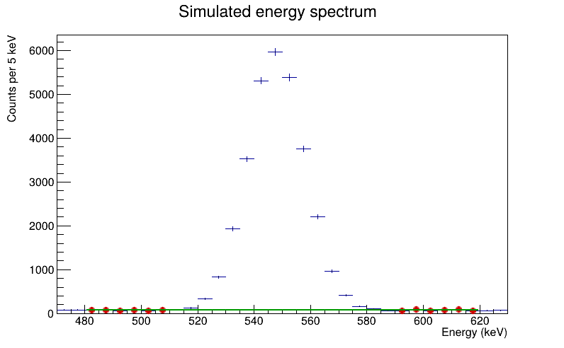

`RSQ0` 中 R 使用函数范围，S 返回拟合结果，Q 减少屏幕输出，0 表示暂不把拟合函数画在 graph 上。这里随后把直线叠加到完整峰区。本底拟合的两个参数将在下一步作为联合拟合的初值。

### 4.3 峰与本底的联合拟合

在 480–620 keV 内使用 `gaus(0)+pol1(3)`：参数 0、1、2 是 Gaussian 的 height、mean 和 sigma，参数 3、4 是线性本底的截距和斜率。

Gaussian 的 mean 取峰区最大 bin 的中心，height 取该 bin 计数减去本底估计，sigma 从图上估计为 10 keV；线性本底参数沿用 sideband 拟合结果。合理的初值可以避免 minimizer 从与数据相差很远的位置开始搜索。

```
peak_bin = hspec.FindBin(510)
for b in range(hspec.FindBin(510), hspec.FindBin(590)):
    if hspec.GetBinContent(b) > hspec.GetBinContent(peak_bin):
        peak_bin = b

mean0 = hspec.GetBinCenter(peak_bin)
height0 = hspec.GetBinContent(peak_bin) - background_line.Eval(mean0)
sigma0 = 10.0

fit_peak_548 = ROOT.TF1("fit_peak_548", "gaus(0)+pol1(3)", 480, 620)
fit_peak_548.SetParNames("height", "mean", "sigma", "background", "slope")
fit_peak_548.SetParameters(
    height0, mean0, sigma0,
    background_line.GetParameter(0), background_line.GetParameter(1)
)
fit_peak_548.SetParLimits(0, 0, 100000)
fit_peak_548.SetParLimits(1, 510, 590)
fit_peak_548.SetParLimits(2, 0.1, 40)

print("Initial height, mean, sigma:", height0, mean0, sigma0)
print("Initial background p0, p1:", background_line.GetParameter(0), background_line.GetParameter(1))
```

```
Initial height, mean, sigma: 5897.152511426981 547.5 10.0
Initial background p0, p1: 92.75668910048645 -0.032710868543318346
```

`Fit(..., "LIRS")` 中：L 使用 binned Poisson likelihood；I 在每个 bin 内对模型积分取平均；R 使用函数定义的拟合范围；S 返回拟合结果及 covariance matrix。联合拟合会同时调整峰和本底参数，sideband 结果只是初值。

下图红线是完整的 Gaussian + linear background 模型，绿色虚线是联合拟合得到的本底分量。两条曲线都覆盖 sidebands 和 peak 区域。

```
peak_fit_result = hspec.Fit(fit_peak_548, "LIRS")
fitted_background = ROOT.TF1("fitted_background", "pol1", 480, 620)
fitted_background.SetParameters(
    fit_peak_548.GetParameter(3), fit_peak_548.GetParameter(4)
)

hspec.GetXaxis().SetRangeUser(470, 630)
c1.Clear()
hspec.Draw("E")
fit_peak_548.SetLineColor(ROOT.kRed + 1)
fit_peak_548.Draw("SAME")
fitted_background.SetLineColor(ROOT.kGreen + 2)
fitted_background.SetLineStyle(2)
fitted_background.Draw("SAME")
c1.Draw()
```

```
Minimizer is Minuit2 / Migrad
MinFCN                    =      14.8711
Chi2                      =      29.7421
NDf                       =           23
Edm                       =  4.78666e-09
NCalls                    =          144
height                    =      5962.56   +/-   43.8631      	 (limited)
mean                      =      547.913   +/-   0.0617975    	 (limited)
sigma                     =      10.0305   +/-   0.0494087    	 (limited)
background                =      82.8929   +/-   23.2866
slope                     =   -0.0128031   +/-   0.0419971
```

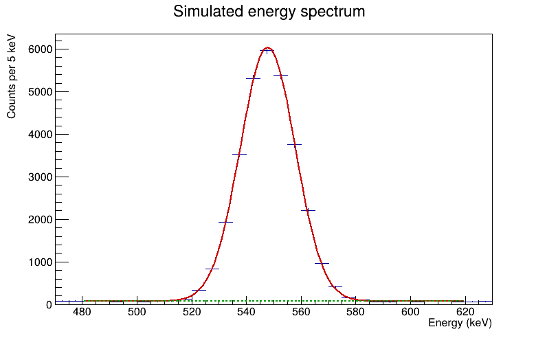

```
peak_height = fit_peak_548.GetParameter(0)
peak_mean = fit_peak_548.GetParameter(1)
peak_sigma = fit_peak_548.GetParameter(2)
bin_width = hspec.GetBinWidth(1)
area_scale = ROOT.TMath.Sqrt(2 * ROOT.TMath.Pi()) / bin_width
peak_area = area_scale * peak_height * peak_sigma

fit_result = peak_fit_result.Get()
var_height = fit_result.CovMatrix(0, 0)
var_sigma = fit_result.CovMatrix(2, 2)
cov_height_sigma = fit_result.CovMatrix(0, 2)
area_variance = area_scale**2 * (
    peak_sigma**2 * var_height
    + peak_height**2 * var_sigma
    + 2 * peak_height * peak_sigma * cov_height_sigma
)
area_error = ROOT.TMath.Sqrt(max(area_variance, 0.0))

print("Fit status:", int(peak_fit_result))
print("Mean:", peak_mean, "+/-", fit_peak_548.GetParError(1), "keV")
print("Sigma:", peak_sigma, "+/-", fit_peak_548.GetParError(2), "keV")
print("FWHM:", 2.35482 * peak_sigma, "+/-", 2.35482 * fit_peak_548.GetParError(2), "keV")
print("Fitted background p0, p1:", fit_peak_548.GetParameter(3), fit_peak_548.GetParameter(4))
print("Gaussian area:", peak_area, "+/-", area_error, "counts")
print("Cov(height, sigma):", cov_height_sigma)
```

```
Fit status: 0
Mean: 547.912850335577 +/- 0.06179746177912193 keV
Sigma: 10.030549768698704 +/- 0.04940868351727179 keV
FWHM: 23.62013920632708 +/- 0.11634855612014196 keV
Fitted background p0, p1: 82.89291995584088 -0.012803089802491724
Gaussian area: 29983.16847672527 +/- 178.54626023362655 counts
Cov(height, sigma): -1.2834784256546472
```

对固定 bin 宽度 \(\Delta E\)，拟合函数的 Gaussian height 为每 bin 的计数尺度，因此 Gaussian 成分的总面积为

\[N_{\rm peak}=\frac{\sqrt{2\pi}}{\Delta E}H\sigma.\]

height 与 sigma 来自同一次拟合，通常相关。令 \(K=\sqrt{2\pi}/\Delta E\)，用拟合 covariance matrix 传播误差：

\[\sigma_N^2=K^2\left(\sigma^2 C_{HH}+H^2 C_{\sigma\sigma}+2H\sigma C_{H\sigma}\right).\]

若只把 height 和 sigma 的误差分别平方相加，会漏掉 covariance 项。这里的面积是拟合所得 Gaussian 成分的积分，不包括线性本底。FWHM 只与 sigma 相差固定系数，误差也按同一系数换算。

残差（residual）是同一 bin 中观测计数减去拟合期望计数。由于拟合使用 I 选项，下面用函数在每个 bin 内的积分除以 bin 宽度计算期望值。

```
residual = ROOT.TGraph()
for b in range(hspec.FindBin(480), hspec.FindBin(620)):
    low = hspec.GetBinLowEdge(b)
    width = hspec.GetBinWidth(b)
    expected = fit_peak_548.Integral(low, low + width) / width
    residual.SetPoint(
        residual.GetN(), hspec.GetBinCenter(b),
        hspec.GetBinContent(b) - expected
    )
residual.SetTitle("Fit residual;Energy (keV);Observed - fitted counts")
residual.SetMarkerStyle(20)
c1.Clear()
residual.Draw("AP")
c1.Draw()
```

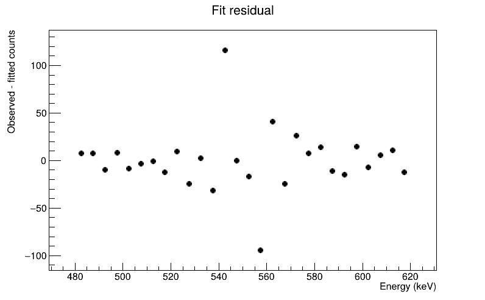

### 4.4 坐标范围与对数坐标

`SetRangeUser` 改变显示的 x 范围；`SetLogy()` 开启对数 y 轴，`SetLogy(0)` 恢复线性 y 轴。`SetLogx()` 同理，但 x 范围需为正值，布拉格曲线中会用到。下面恢复完整能谱显示，不改变各 bin 的内容。

直方图被设置轴范围后，`GetMean()` 等统计量也可能按选定范围重新计算；要查看整幅能谱的统计量，应先恢复完整轴范围。

```
hspec.GetXaxis().SetRange(0, 0)  # 恢复完整的 x 轴范围
c1.Clear()
c1.SetLogy()
hspec.Draw()
c1.Draw()
```

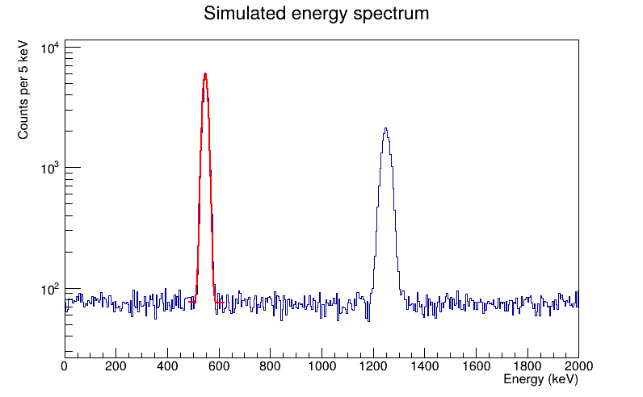

## 5. `TH2`：二维直方图

二维直方图统计成对数值，而不是单个数值。在探测器分析中，这两个量应属于同一次测量或同一个事例，例如束斑坐标 `(x, y)`、望远镜中两层探测器的信号，或粒子鉴别图中的两个观测量。

`TH2` 是二维直方图的基类。本例采用 `TH2F`，其 bin 内容用单精度浮点数保存。

### 5.1 探测器平面上的束斑

假设位置灵敏探测器给出每个粒子的 x、y 坐标。构造函数为

```
ROOT.TH2F(name, title, nx, xmin, xmax, ny, ymin, ymax)
```

x 轴在 `xmin` 到 `xmax` 之间划分 `nx` 个 bin，y 轴同理。下面两个轴都在 −30 到 30 mm 之间划分 120 个 bin，每个方向的 bin 宽度均为 0.5 mm。

```
c1.SetLogy(0)
hxy = ROOT.TH2F(
    "hxy",
    "Beam spot on detector plane;x (mm);y (mm)",
    120, -30.0, 30.0,
    120, -30.0, 30.0,
)

r2 = ROOT.TRandom3(13579)

for i in range(50000):
    x_position = r2.Gaus(2.0, 6.0)
    y_position = r2.Gaus(-1.0, 4.0)
    hxy.Fill(x_position, y_position)

c1.Clear()
hxy.Draw("COLZ")
c1.Draw()
```

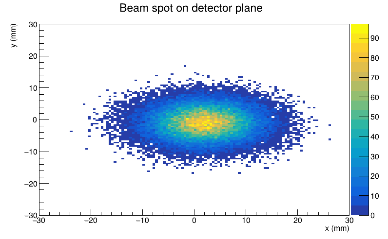

`Gaus(2.0, 6.0)` 生成均值 2 mm、sigma 为 6 mm 的 x；`Gaus(-1.0, 4.0)` 生成均值 −1 mm、sigma 为 4 mm 的 y。一次循环中的坐标对代表一个被探测的粒子，通过 `Fill(x, y)` 填入直方图。

`Draw("COLZ")` 中，`COL` 用颜色表示 bin 内容，`Z` 添加颜色标尺。这里 x、y 独立采样；`TH2` 显示的是联合分布，但画成二维图本身并不意味着两个量存在物理关联。

```
print(f"Entries = {hxy.GetEntries():.0f}")
print(f"Mean x  = {hxy.GetMean(1):.3f} mm")
print(f"Mean y  = {hxy.GetMean(2):.3f} mm")
print(f"Std dev x   = {hxy.GetStdDev(1):.3f} mm")
print(f"Std dev y   = {hxy.GetStdDev(2):.3f} mm")
```

```
Entries = 50000
Mean x  = 2.023 mm
Mean y  = -1.006 mm
Std dev x   = 6.025 mm
Std dev y   = 3.984 mm
```

对于 `TH2`，轴编号 1 表示 x，2 表示 y。计算出的均值和标准差应接近生成位置分布时使用的参数。真实束斑分析会用实测位置代替随机样本，填充和显示操作相同。

### 5.2 选定 y 区间后作 x 投影

假设只关心穿过 `−3 ≤ y < 1 mm` 水平区域的粒子，查看它们在 x 方向上的分布。`ProjectionX` 沿 y 方向累加，得到 x 分布；`ProjectionY` 则沿 x 方向累加。

`ProjectionX(name,first_y_bin,last_y_bin)` 指定要累加的 y 轴 bin，两端均包含。这里边界与 bin 边缘重合，最后一个 bin 用 `FindBin(1)-1`。不指定范围时，默认累加整个 y 轴，包括 underflow 和 overflow。

```
px = hxy.ProjectionX("px")
first_y_bin = hxy.GetYaxis().FindBin(-3)
last_y_bin = hxy.GetYaxis().FindBin(1) - 1
px_gate = hxy.ProjectionX("px_gate", first_y_bin, last_y_bin)
all_counts = px.Integral(0, px.GetNbinsX() + 1)
gate_counts = px_gate.Integral(0, px_gate.GetNbinsX() + 1)
print("All events:", all_counts)
print("Events in y gate:", gate_counts)
print("Accepted fraction:", gate_counts / all_counts)
```

```
All events: 50000.0
Events in y gate: 19236.0
Accepted fraction: 0.38472
```

二维图上的红线给出选择边界；右图叠加全部事例和所选事例的 x 分布。`SetLineColor` 只改变显示颜色，真正的选择由前面的 y 轴 bin 范围完成。

```
cProjection = ROOT.TCanvas("cProjection", "Position gate and projection", 1100, 460)
cProjection.Divide(2, 1)
cProjection.cd(1)
hxy.Draw("COLZ")
gate_low = ROOT.TLine(-30, -3, 30, -3)
gate_high = ROOT.TLine(-30, 1, 30, 1)
for line in [gate_low, gate_high]:
    line.SetLineColor(ROOT.kRed + 1)
    line.Draw()
cProjection.cd(2)
px.SetTitle("x projection; x (mm);Counts / 0.5 mm")
px.SetLineColor(ROOT.kBlack)
px.Draw("HIST")
px_gate.SetLineColor(ROOT.kRed + 1)
px_gate.Draw("HIST SAME")
legend = ROOT.TLegend(0.60, 0.72, 0.88, 0.88)
legend.AddEntry(px, "All events", "l")
legend.AddEntry(px_gate, "y gate", "l")
legend.Draw()
cProjection.Draw()
```

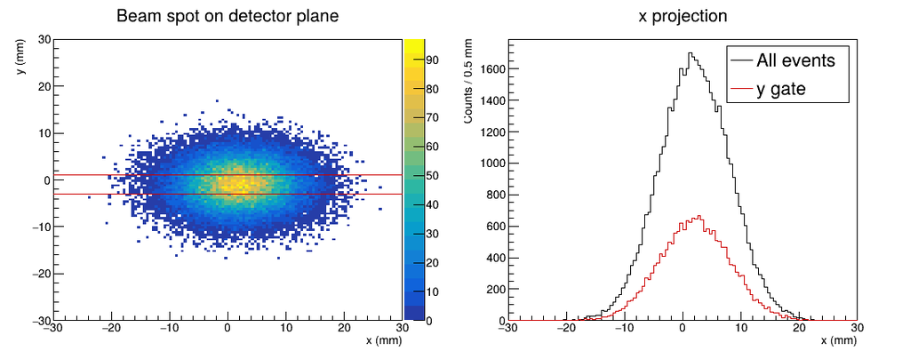

本例 x、y 独立采样，因此 y gate 主要减少计数，所选 x 分布的中心和宽度基本不变。如果两个量存在关联，条件投影的形状也会改变。

固定电荷区间内作 PSD 投影，以及望远镜中选定某类事例后查看其他测量量，都采用这种分析思路。已有二维直方图的范围选择按 bin 进行；TTree 中的逐事例条件和 graphical cut 见 Tutorial II。

## 6. `TFile`：保存和读回 ROOT 对象

`TFile` 按 ROOT 内部名称保存图、直方图、函数等对象。写入对象不同于保存图片：ROOT 文件保留数值对象，之后可以重新读取和分析。

### 6.1 将对象写入 ROOT 文件

构造函数需要文件名和打开模式：

```
ROOT.TFile(filename, mode)
```

`RECREATE` 创建文件，若同名文件已存在则覆盖；`READ` 只读打开已有文件；`UPDATE` 在保留已有内容的情况下允许读写。使用 `RECREATE` 前先核对文件名。

`fout.cd()` 将 `fout` 设为当前 ROOT 目录，各对象的 `Write()` 按内部名称写入该目录；`Close()` 完成写入并关闭文件。

```
fout = ROOT.TFile("root_tutorial1.root", "RECREATE")
fout.cd()

gcal.Write()
hspec.Write()
hxy.Write()
px_gate.Write()

fout.Close()
```

文件保存 `gcal`、`hspec`、`hxy` 和条件投影 `px_gate`。ROOT 按对象的内部名称保存，名称来自构造函数或 `SetName`，不由 C++ 或 Python 变量名决定。

### 6.2 打开文件并查看内容

`Open` 打开刚才写出的文件，`ls()` 列出其中的对象。若打不开课程数据文件，先检查文件名和位置。

```
fin = ROOT.TFile.Open("root_tutorial1.root", "READ")
fin.ls()
```

```
TFile**		root_tutorial1.root
 TFile*		root_tutorial1.root
  KEY: TGraphErrors	gcal;1	Energy calibration
  KEY: TH1F	hspec;1	Simulated energy spectrum
  KEY: TH2F	hxy;1	Beam spot on detector plane
  KEY: TH1D	px_gate;1	Beam spot on detector plane
```

### 6.3 读回一个对象

`Get(name)` 读取以 `name` 保存的对象。从 ROOT 文件中读出的直方图通常与该文件关联，因此使用它时保持输入文件打开。

```
hread = fin.Get("hspec")
c1.cd()
c1.Clear()
hread.Draw()
c1.Draw()
```

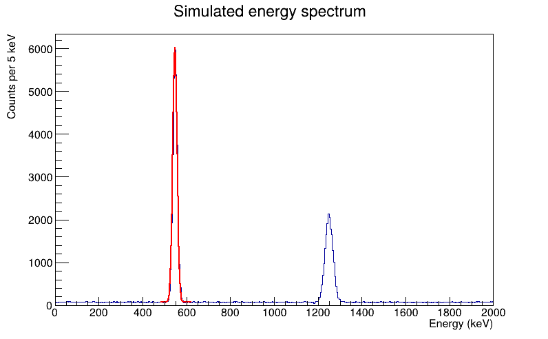

这三个操作的作用不同：

- `Draw()` 在画布上显示对象。
- `Write()` 将对象写入当前输出文件。
- `Get()` 按 ROOT 对象名从文件中读取对象。

不再使用读出的对象后，再关闭文件。关闭后不要继续使用 `hread`，除非重新读取，或已明确解除它与文件的关联。

```
fin.Close()
```

## 小结

`TF1` 表示一维函数模型，`TGraph` 保存坐标对，`TRandom3` 通过 `Gaus`、`Uniform`、`Poisson` 等方法生成相应分布的伪随机数。`TH1F`、`TH2F` 分别累积一维、二维分布，`TFile` 用于保存 ROOT 对象。

后续分析中要注意这些区别：

- 函数模型不是逐个事例的数据集合；
- TGraph 保存数据点，直方图保存各 bin 的内容；
- 随机数发生器本身不是某一种概率分布；
- 显示对象与将对象写入文件是不同操作。

### ROOT 参考文档

- [PyROOT 与 JupyROOT](https://root.cern/manual/python/)
- [`TF1`](https://root.cern.ch/doc/master/classTF1.html) 与 [`TGraph`](https://root.cern.ch/doc/master/classTGraph.html)
- [`TRandom3`](https://root.cern.ch/doc/master/classTRandom3.html)
- [`TH1`](https://root.cern.ch/doc/master/classTH1.html) 与 [`TH2`](https://root.cern.ch/doc/master/classTH2.html)
- [`TFile`](https://root.cern.ch/doc/master/classTFile.html)

[TGraph 拟合选项与 x 误差处理](https://root.cern.ch/doc/master/classTGraph.html) · [TGraphErrors](https://root.cern.ch/doc/master/classTGraphErrors.html)